# Python Data Science

> Data Visualization with Matplotlib

Kuo, Yao-Jen yaojenkuo@datainpoint.com from [DATAINPOINT](https://www.datainpoint.com/)

```python
import numpy as np
from PIL import Image
```

## TL; DR

> In this lecture, we will talk about essential data visualization skills in `matplotlib.pyplot`.

## About Matplotlib

## What is `matplotlib`?

> Matplotlib, short for matix plotting library is a comprehensive library for creating static, animated, and interactive visualizations in Python.

Source: https://matplotlib.org/

## Import Matplotlib with `import` command

Matplotlib is officially aliased as `mpl`.

```python
import matplotlib as mpl
```

## If Matplotlib is not installed, we will encounter a `ModuleNotFoundError`

```
Traceback (most recent call last):
  File "<stdin>", line 1, in <module>
ModuleNotFoundError: No module named 'matplotlib'
```

## Use `pip install` at Terminal to install matplotlib

```
pip install matplotlib
```

## Check version and its installation file path

- `__version__` attribute
- `__file__` attribute

```python
print(mpl.__version__)
print(mpl.__file__)
```

```
3.3.2
/opt/conda/lib/python3.8/site-packages/matplotlib/__init__.py
```

## We will use `matplotlib.pyplot` through this chapter, which is a plotting module in matplotlib, officially aliased as `plt`

```python
import matplotlib.pyplot as plt
```

## Why `matplotlib`?

> Visualization plays a vital role among exploratory data analysis. Sometimes it is extremly difficult for human to understand raw data, functions, or formulas.

## The abstractness of raw data

```python
arr = np.random.normal(size=10000)
arr
```

```
array([ 0.46552347,  1.09230233, -1.45207542, ..., -0.90509376,
       -0.01143045, -0.11561234])
```

## The abstractness of functions

Considering 2 functions below:

\begin{equation} f(p) = -log(p) \\ f(p) = -log(1-p) \end{equation}

## The abstractness of formulas

\begin{equation} f(x) = \frac{1}{1 + e^{-x}} \end{equation}

## The concreteness of visualization for raw data

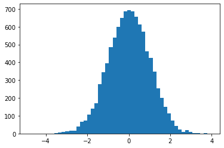

```python
fig = plt.figure()
ax = plt.axes()
ax.hist(arr, bins=50)
plt.show()
```

## The concreteness of visualization for functions

```python
eps = 1e-06 # epsilon, a tiny number to avoid infinity
p = np.linspace(0 + eps, 1 - eps, 10000)
log_loss_0 = -np.log(1-p)
log_loss_1 = -np.log(p)
```

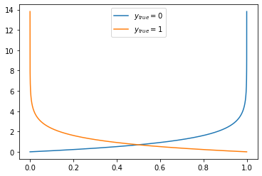

```python
fig = plt.figure()
ax = plt.axes()
ax.plot(p, log_loss_0, label='$y_{true}=0$')
ax.plot(p, log_loss_1, label='$y_{true}=1$')
ax.legend()
plt.show()
```

## The concreteness of visualization for formulas

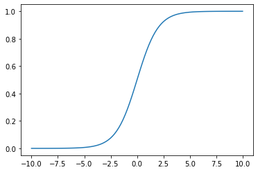

```python
x = np.linspace(-10, 10, 100)
fx = 1 / (1 + np.exp(-x))
fig = plt.figure()
ax = plt.axes()
ax.plot(x, fx)
plt.show()
```

## The classic visualizations of all time

- [Charles Minard's map of Napoleon's disastrous Russian campaign of 1812](https://en.wikipedia.org/wiki/Charles_Joseph_Minard#/media/File:Minard.png).
- [Hans Rosling's 200 Countries, 200 Years, 4 Minutes](https://youtu.be/jbkSRLYSojo).

## Characteristics of a good visualization

- Informative
- Simple
- Pretty

## Two ways to plot

## The most challenging part for matplotlib newbies is its various plotting syntaxes

## There are 2 plotting syntaxes to adapt

- Matlab style.
- Object-oriented style.

## Plotting with matlab style: stateful interface

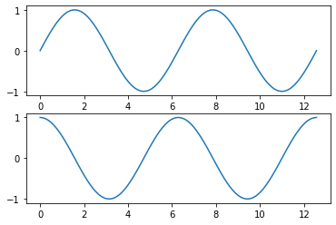

```python
x = np.linspace(0, np.pi*4, 100)
plt.figure()
plt.subplot(2, 1, 1)
plt.plot(x, np.sin(x))
plt.subplot(2, 1, 2)
plt.plot(x, np.cos(x))
plt.show()
```

## Plotting with object-oriented style: object method interface

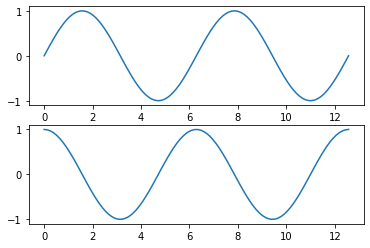

```python
fig, axes = plt.subplots(2, 1)
axes[0].plot(x, np.sin(x))
axes[1].plot(x, np.cos(x))
plt.show()
```

## We will adapt the object-oriented style.

## The general steps

## The general steps to create plots are:

1. Creating arrays.
2. Generating figure and axes objects(respectively or simultaneously).
3. Calling various methods of axes object to generate main plot.
4. Calling various methods of axes object to add elements.
5. Show or save plots.

## Creating arrays

```python
x = np.linspace(0, np.pi*4, 100)
y = np.sin(x)
```

## Generating figure and axes objects respectively

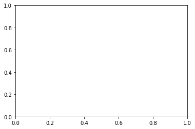

```python
fig = plt.figure()
axes = plt.axes()
```

## Generating figure and axes objects simultaneously

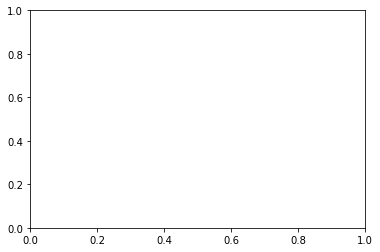

```python
fig, axes = plt.subplots()
```

## Calling various methods of axes object to generate main plot

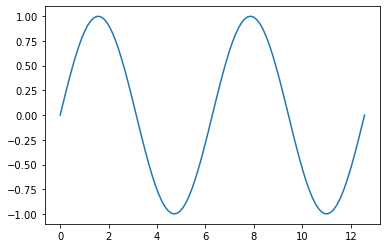

```python
fig = plt.figure()
axes = plt.axes()
axes.plot(x, y)
```

## Calling various methods of axes object to add elements

```python
fig = plt.figure()
axes = plt.axes()
axes.plot(x, y)
axes.set_title('A simple plot')
axes.set_xlabel('x')
```

[output not shown]

## Show plots

```python
fig = plt.figure()
axes = plt.axes()
axes.plot(x, y)
axes.set_title('A simple plot')
axes.set_xlabel('x')
plt.show()
```

[output not shown]

## Save plots

Various format is supported.

```python
fig = plt.figure()
fig.canvas.get_supported_filetypes()
```

```
{'eps': 'Encapsulated Postscript',
 'jpg': 'Joint Photographic Experts Group',
 'jpeg': 'Joint Photographic Experts Group',
 'pdf': 'Portable Document Format',
 'pgf': 'PGF code for LaTeX',
 'png': 'Portable Network Graphics',
 'ps': 'Postscript',
 'raw': 'Raw RGBA bitmap',
 'rgba': 'Raw RGBA bitmap',
 'svg': 'Scalable Vector Graphics',
 'svgz': 'Scalable Vector Graphics',
 'tif': 'Tagged Image File Format',
 'tiff': 'Tagged Image File Format'}
```

```python
fig = plt.figure()
axes = plt.axes()
axes.plot(x, y)
axes.set_title('A simple plot')
axes.set_xlabel('x')
fig.savefig('a_simple_plot.png')
```

[output not shown]

## Different methods for different plot types

- `scatter` for scatter plots.
- `hist` for histograms.
- `plot` for lines.
- `bar` for bar plots.
- `imshow` for showing images in `ndarray` format.
- ...etc.

## `scatter` for scatter plots

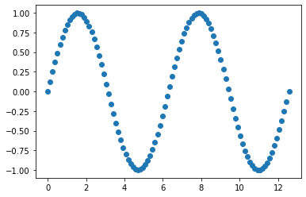

```python
fig = plt.figure()
axes = plt.axes()
axes.scatter(x, y)
plt.show()
```

## `hist` for histograms

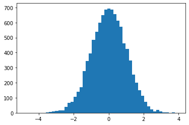

```python
fig = plt.figure()
axes = plt.axes()
axes.hist(arr, bins=50)
plt.show()
```

## `plot` for lines

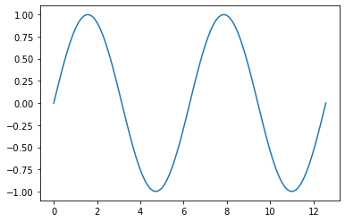

```python
fig = plt.figure()
axes = plt.axes()
axes.plot(x, y)
plt.show()
```

## `bar` for bar plots

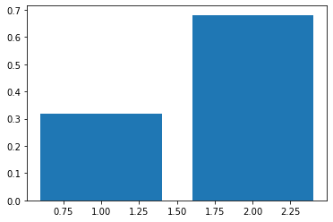

```python
outside_one_std = np.sum((arr > 1) | (arr < -1)) / arr.size
within_one_std = np.sum((-1 <= arr) & (arr <= 1)) / arr.size
y = [outside_one_std, within_one_std]
x = [1, 2]
fig = plt.figure()
axes = plt.axes()
axes.bar(x, y)
plt.show()
```

## `imshow` for showing images in `ndarray` format

[figure not shown]

```python
!curl -o a_very_cute_schnauzer.jpg https://i.imgur.com/hTFmWKO.jpg?1
pic = Image.open('a_very_cute_schnauzer.jpg')
arr = np.array(pic)
print(arr.shape)
```

```
  % Total    % Received % Xferd  Average Speed   Time    Time     Time  Current
                                 Dload  Upload   Total   Spent    Left  Speed
100 24876  100 24876    0     0  36853      0 --:--:-- --:--:-- --:--:-- 36798
(459, 344, 3)
```

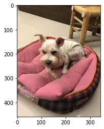

```python
fig = plt.figure()
axes = plt.axes()
axes.imshow(arr)
plt.show()
```

## Techniques for adding elements

## How to add title and axis labels

- `set_title` to add title.
- `set_xlabel` to add x-axis label.
- `set_ylabel` to add y-axis label.

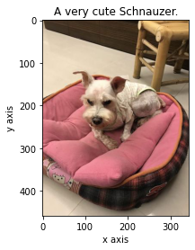

```python
fig = plt.figure()
axes = plt.axes()
axes.imshow(arr)
axes.set_title('A very cute Schnauzer.')
axes.set_xlabel('x axis')
axes.set_ylabel('y axis')
plt.show()
```

## How to adjust axis ticks

- `set_xticks` to adjust x-axis ticks.
- `set_yticks` to adjust y-axis ticks.

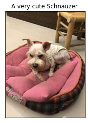

```python
fig = plt.figure()
axes = plt.axes()
axes.imshow(arr)
axes.set_title('A very cute Schnauzer.')
axes.set_xticks([])
axes.set_yticks([])
plt.show()
```

## How to adjust axis tick labels

- `set_xticklabels` to adjust x-axis tick labels.
- `set_yticklabels` to adjust y-axis tick labels.

```python
arr = np.random.normal(size=10000)
outside_one_std = np.sum((arr > 1) | (arr < -1)) / arr.size
within_one_std = np.sum((-1 <= arr) & (arr <= 1)) / arr.size
y = [outside_one_std, within_one_std]
x = [1, 2]
```

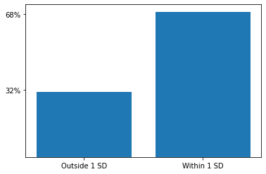

```python
fig = plt.figure()
axes = plt.axes()
axes.bar(x, y)
axes.set_xticks([1, 2])
axes.set_yticks([0.32,  0.68])
axes.set_xticklabels(['Outside 1 SD', 'Within 1 SD'])
axes.set_yticklabels(['32%', '68%'])
plt.show()
```

## How to adjust axis limits

- `set_xlim` to adjust the upper/lower limits of x-axis.
- `set_ylim` to adjust the upper/lower limits of y-axis.

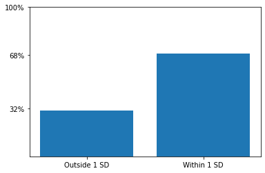

```python
fig = plt.figure()
axes = plt.axes()
axes.bar(x, y)
axes.set_xticks([1, 2])
axes.set_yticks([0.32,  0.68, 1])
axes.set_xticklabels(['Outside 1 SD', 'Within 1 SD'])
axes.set_yticklabels(['32%', '68%', '100%'])
axes.set_ylim([0, 1])
plt.show()
```

## How to add texts

`text(x, y, 'Some Strings')` to add `'Some Strings'` at (x, y).

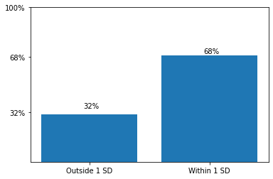

```python
fig = plt.figure()
axes = plt.axes()
axes.bar(x, y)
axes.set_xticks([1, 2])
axes.set_yticks([0.32,  0.68, 1])
axes.set_xticklabels(['Outside 1 SD', 'Within 1 SD'])
axes.set_yticklabels(['32%', '68%', '100%'])
axes.set_ylim([0, 1])
axes.text(1 - 0.05, 0.35, '32%')
axes.text(2 - 0.05, 0.70, '68%')
plt.show()
```

## How to add legends

`lenged()` and `label` parameterto add a legend to indicate categories.

```python
x = np.linspace(0, np.pi*4, 100)
y_sin = np.sin(x)
y_cos = np.cos(x)
```

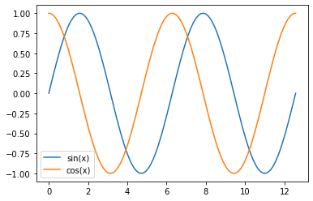

```python
fig = plt.figure()
axes = plt.axes()
axes.plot(x, y_sin, label='sin(x)')
axes.plot(x, y_cos, label='cos(x)')
axes.legend()
plt.show()
```

## How to create a subplot grid?

- `subplots(m, n)` to create a `ndarray` with a shape `(m, n)`.
- There are (m, n) axes objects inside the `ndarray`.
- Access axes objects through `[m, n]`.

```
<class 'numpy.ndarray'>
(2, 3)
```

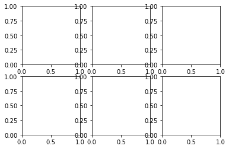

```python
fig, axes = plt.subplots(2, 3)
print(type(axes))
print(axes.shape)
```

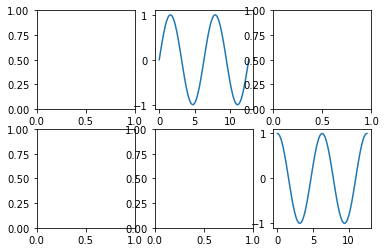

```python
x = np.linspace(0, 4*np.pi, 100)
y_sin = np.sin(x)
y_cos = np.cos(x)
fig, axes = plt.subplots(2, 3)
axes[0, 1].plot(x, y_sin)
axes[1, 2].plot(x, y_cos)
plt.show()
```